# Chiago Public Schools College Enrollement and School Type Analysis

Final Project  
Data Science 1 with R (STAT 301-1)

Author

Sarah Villamil

Published

December 10, 2025

**Github Repo Link**

[My Git Hub Link](https://github.com/stat301-1-2025-fall/final-project-1-sarahvillamil)

## Introduction

In this report, I analyzed the [Chicago Public Schools Data](https://data.cityofchicago.org/Education/Chicago-Public-Schools-School-Progress-Reports-SY2/twrw-chuq/about_data) sourced from [City of Chicago Website](https://www.cps.edu/). This data set is a 2024 school progress report ratings for all Chicago Public Schools, based on 2022-2023 data. Given that the Chicago demographic data is from 2023, only the Chicago Public Schools 2023 data was explored in this report. For further analysis, I joined this dataset with the [Chicago Demographic Data](https://data.cityofchicago.org/Community-Economic-Development/ACS-5-Year-Data-by-Community-Area/t68z-cikk/data_preview) sourced from the [City of Chicago Data Portal](https://data.cityofchicago.org/). Both of these datasets were first accessed in October 24, 2025.

I chose to explore these data sets because I wanted to learn more about how college enrollment percents differ based on school types and demographic data. Based on my initial exploration, selective enrollment schools had high college enrollment and graduation rates and I am interested to see what other relations and associations can be drawn from school type. How accessible are these college preparation programs within these selective enrollment schools to the greater Chicago community? It should be noted that throughout this report there exists a notion that college is the desired result/measure of success out of high school which may not true for every student or school. How does a school location and corresponding demographics in Chicago affect their college enrollment rate? What variables such a student attendance, college persistence rate, and graduation rates could schools target to improve college enrollments. I believe that more research in this area is needed to emphasize the importance of certain programs to encourage the increase in budgets for Chicago Public Schools.

Research Question 1: What variables could schools target to improve college enrollment rates?

Research Question 2: How can a school type affect a student’s post-high school outcomes?

## Data Overview & Quality

The Chicago Public School’s data, consists of six-hundred-forty-nine schools spanning from elementary to high schools. There are 183 columns with 649 observations. The variables include datatypes from numerical such as school_id, zip code, student_attendance rates, and college enrollment data to categorical such as the school’s address, school’s safety score, and it’s name. There are 121 categorical variables and 62 numerical variables. This data set was last updated on December 9th, 2025. Each year, a new dataset is released by the City of Chicago. The data provided by the Chicago Public Schools and by Ted Canji[^1].

<sup>1</sup> Web Production Manager at Chicago Public Schools

The Chicago Community Data provides 2023 demographic and income data based on Chicago’s community areas as per the data collected by the [American Community Survey Data](https://www.census.gov/programs-surveys/acs/data.html). There are 30 columns with 77 observations. The variables include two categorical and 28 numerical with demographics such as income level, age, race, and ethnicity. Further description of this data set can be found on the [Chicago Data Portal](https://data.cityofchicago.org/Community-Economic-Development/ACS-5-Year-Data-by-Community-Area/t68z-cikk/data_preview). This dataset had zero missingness across all variables. It should be noted that age ranges that were intially separated by gender in the dataset were combined as gender is not a demographic to be explored in my analysis. This dataset was last updated on January 23, 2025. This dataset was further joined with Chicago neighborhood and zipcode data provided by Professor Sass.

When these datasets were joined the new dataset which is used for this report had 39 columns with 1298 observations. Of these, 17 were categorical variables and 22 were numeric variables.

In Figure 1, the missingness of the joined dataset can be seen. A lot of this missingness is due to the inconsistent metrics of data collection across all schools. Many variables had no distinct value across all observations and were removed due to their lack of insight to the analysis. Another inefficiency in data collection was that averages across all Chicago public schools were stored within the data set, but if graphed these variables would have a zero slope. These variables are reflected in the code book but removed for the analysis.

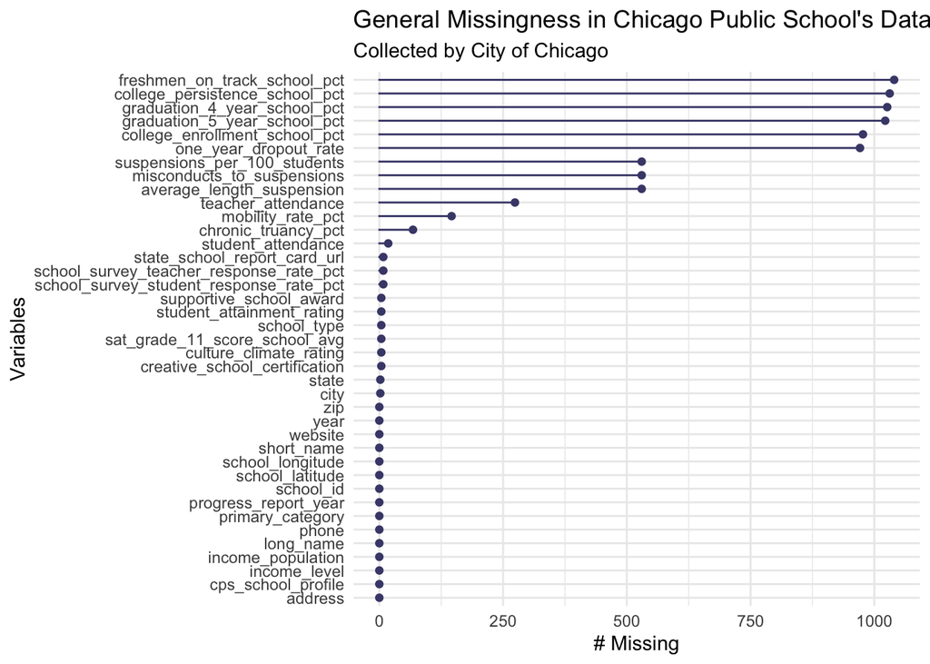

Figure 1: General Missingness in Chicago Public School Data

After tidying, pivoting, and intentionally choosing the variables to explore, I was able to reduce missingness especially for the college enrollment variable. I focused on high school’s in the dataset as elementary and middle schools are unlikely to have data on their college enrollment, which could have caused null values. This change in null values is refected in Table 1. It should be noted that some high school’s had null values for college enrollment percent. This may be due to inconsistent data collection or focus on non-college post high school options. However, as seen in Table 1, the percent missing for college enrollment percent was reduced to less than seven percent missing.

Table 1: Top Missingness in Chicago Public High School Data

Missingness of Variables in Chicago Public High School Data

| variable | n_miss | pct_miss |
| --- | --- | --- |
| suspensions_per_100_students | 156 | 45.9 |
| misconducts_to_suspensions | 156 | 45.9 |
| average_length_suspension | 156 | 45.9 |
| teacher_attendance | 156 | 45.9 |
| freshmen_on_track_school_pct | 85 | 25 |
| college_persistence_school_pct | 77 | 22.6 |
| graduation_4_year_school_pct | 74 | 21.8 |
| graduation_5_year_school_pct | 70 | 20.6 |
| mobility_rate_pct | 62 | 18.2 |
| chronic_truancy_pct | 46 | 13.5 |
| college_enrollment_school_pct | 23 | 6.76 |

## Explorations

### Research Question 1

What variables could schools target to improve college enrollment rates?

#### Univariate Analysis of College Enrollment

First an uni-variate exploration of the college enrollment rate variable. Figure 2 shows that college enrollments percent vary. However, there is a mean peak in the distribution at around 75% of college enrollment rates.

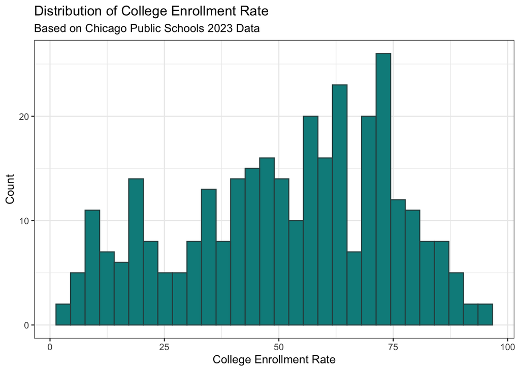

Figure 2: Distribution of College Enrollment Rates for Chicago Public High Schools

Table 2: Top 10 Chicago Public Schools with Highest College Enrollment Rate

Top 10 Chicago Public Schools with Highest College Enrollment Rate

| short_name | school_type | college_enrollment_school_pct |
| --- | --- | --- |
| LANE TECH HS | Selective enrollment | 90.9 |
| LINCOLN PARK HS | Neighborhood | 88.5 |
| YOUNG HS | Selective enrollment | 88.5 |
| JONES HS | Selective enrollment | 87.0 |
| WESTINGHOUSE HS | Selective enrollment | 86.4 |
| LINDBLOM HS | Selective enrollment | 83.1 |
| OGDEN HS | Neighborhood | 82.8 |
| FARRAGUT HS | Neighborhood | 82.4 |
| BACK OF THE YARDS HS | Neighborhood | 81.1 |
| JUAREZ HS | Neighborhood | 79.5 |

Bottom 10 Chicago Public Schools with Lowest College Enrollment Rate

| short_name | school_type | college_enrollment_school_pct |
| --- | --- | --- |
| BOGAN HS | Neighborhood | 44.5 |
| JULIAN HS | Neighborhood | 44.4 |
| ORR HS | Neighborhood | 44.4 |
| HYDE PARK HS | Neighborhood | 42.1 |
| CHICAGO VOCATIONAL HS | Career academy | 41.7 |
| DUNBAR HS | Career academy | 40.7 |
| HARLAN HS | Neighborhood | 36.6 |
| TILDEN HS | Neighborhood | 35.0 |
| AUSTIN CCA HS | Small | 33.3 |
| MARSHALL HS | Neighborhood | 32.1 |

As it can be seen in Table 2, the schools with the highest college enrollment rates tended to be selective enrollment schools. While as seen in Table 3, the lowest college enrollment rates tended to be neighborhood schools.

#### Bivariate Analysis of College Enrollment

I then decided to explore how college enrollment rates were affected by school type in Figure 3. It confirms that selective enrollment schools are the type with the highest college enrollment rates but shows that special education and citywide option school types have the lowest college enrollment rates. This shows that there is another factor affecting college enrollment rates to differ among neighborhood schools that isn’t just school type.

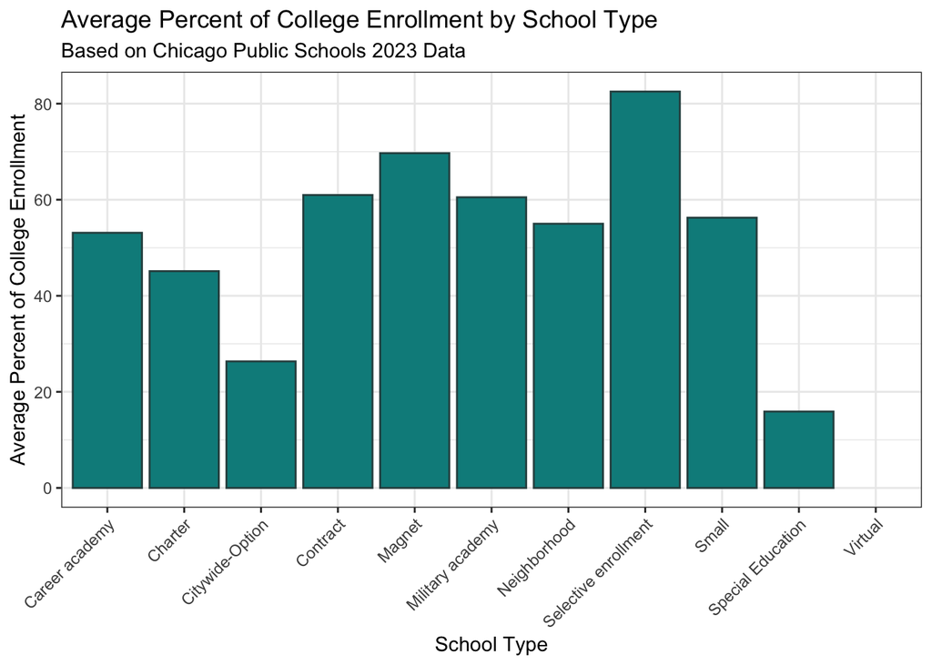

Figure 3: College Enrollment Percents by School Type for Chicago Public High Schools”

Table 4: Chicago Public Schools School Type in Order of Highest College Enrollment Rate

Chicago Public Schools School Type in Order of Highest College Enrollment Rate

| short_name | income_level | college_enrollment_school_pct |
| --- | --- | --- |
| LANE TECH HS | avg_125_000 | 90.9 |
| LINCOLN PARK HS | avg_125_000 | 88.5 |
| YOUNG HS | avg_125_000 | 88.5 |
| JONES HS | avg_125_000 | 87.0 |
| WESTINGHOUSE HS | avg_25_000_to_49_999 | 86.4 |
| LINDBLOM HS | avg_25_000_to_49_999 | 83.1 |
| OGDEN HS | avg_125_000 | 82.8 |
| FARRAGUT HS | avg_25_000_to_49_999 | 82.4 |
| BACK OF THE YARDS HS | avg_25_000_to_49_999 | 81.1 |
| JUAREZ HS | avg_25_000_to_49_999 | 79.5 |

Table 5: Chicago Public Schools School Type in Order of Lowest College Enrollment Rates

Chicago Public Schools School Type in Order of Lowest College Enrollment Rates

| short_name | income_level | college_enrollment_school_pct |
| --- | --- | --- |
| MARSHALL HS | avg_25_000_to_49_999 | 32.1 |
| AUSTIN CCA HS | avg_under_25_000 | 33.3 |
| TILDEN HS | avg_25_000_to_49_999 | 35.0 |
| HARLAN HS | avg_75_000_to_125_000 | 36.6 |
| DUNBAR HS | avg_125_000 | 40.7 |
| CHICAGO VOCATIONAL HS | avg_75_000_to_125_000 | 41.7 |
| HYDE PARK HS | avg_under_25_000 | 42.1 |
| JULIAN HS | avg_125_000 | 44.4 |
| ORR HS | avg_25_000_to_49_999 | 44.4 |
| BOGAN HS | avg_125_000 | 44.5 |

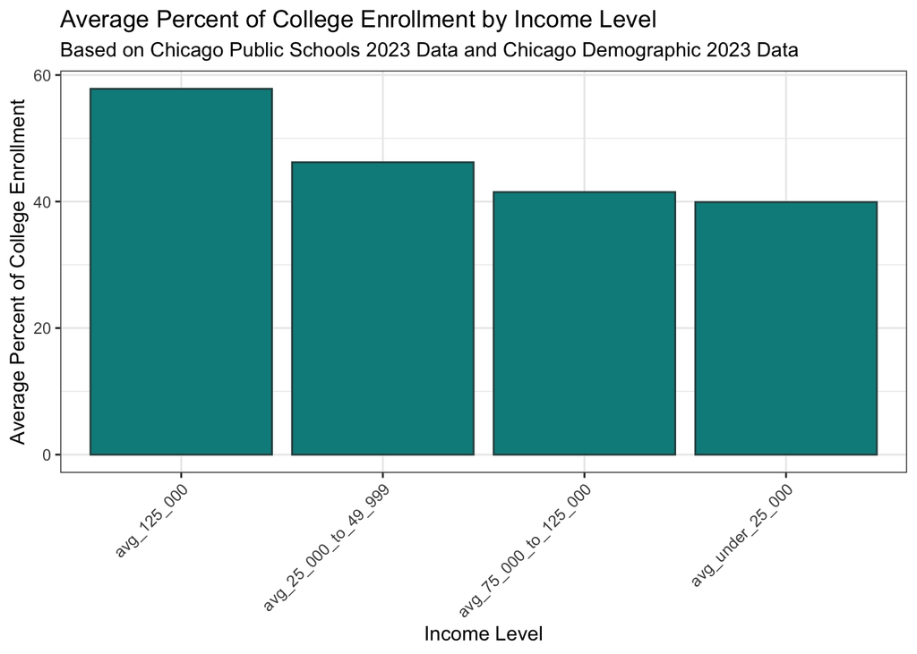

Figure 4: College Enrollment Rates by Income Level for Chicago Public High Schools

Now that I have explored how categorical variables relate to college enrollments percents, I will be exploring numerical variables in a correlation plot, Figure 5

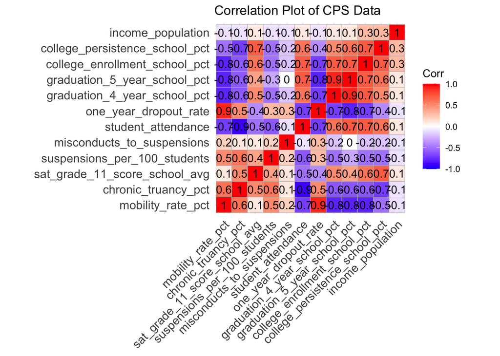

Figure 5: Correlation Plot of Numeric Variables from Chicago Public Schools Data

The correlation plot shows which numeric variables have a strong association with the college enrollment rate. It shows that the variables with the strongest negative association are mobility rates percent, one year drop out rate, and chronic truancy percent. The variables with the strongest positive association are student attendance, college persistence rate, and graduation rate in four and five years.

In my second research question I look how the positive relation between student attendance, college enrollment with college persistence rate, and graduation rate in four and five years can be related to the school’s type.

### Research Question 2

How can a school type affect a student’s post-high school outcomes?

#### School Type Univariable Analysis

Table 6: Count of School Types within the Chicago Public School

Count of School Types within the Chicago Public Schools

| school_type | count |
| --- | --- |
| Charter | 118 |
| Neighborhood | 88 |
| Citywide-Option | 38 |
| Small | 26 |
| Selective enrollment | 22 |
| Magnet | 14 |
| Military academy | 12 |
| Career academy | 8 |
| Special Education | 8 |
| Contract | 4 |
| Virtual | 2 |

However, of these school types, only 10 have recorded data on college enrollment and graduation rates. From research question 1 with Figure 3 we already know that selective enrollment schools have the highest average of college enrollment among students with special-education and citywide option schools at the bottom

It is very clear that school type can have an impact on college enrollment and I was curious how school type could further explain the difference in the other numeric variables related to college enrollment such as student attendance, college enrollment with college persistence rate, and graduation rate in four and five years, as well as SAT scores.

#### School Type Bivariate Analysis

Looking at SAT scores, once again the difference among school types is consistent. Figure 6 show that while most participating CPS high schools do well on the SAT, selective enrollment has the highest average SAT scores and city-wide option has the lowest average SAT scores

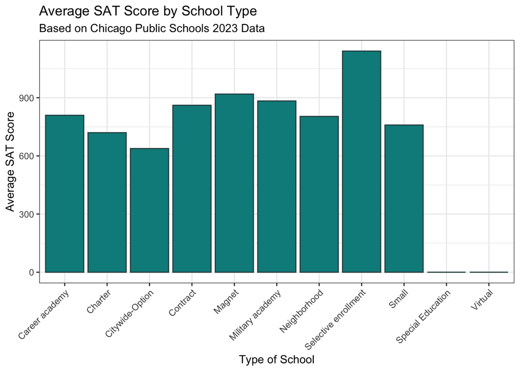

Figure 6: Avg SAT Scores by School Type

The relation of school type to college persistence is shown in Figure 7. In this figure we see similar patterns as shown in college enrollment and SAT scores figures, however the relation between school type and college persistence is not as strong as college enrollment rates. Selective enrollment still has a much higher percent than other schools types. However, citywide option schools are closer in percent to other school types.

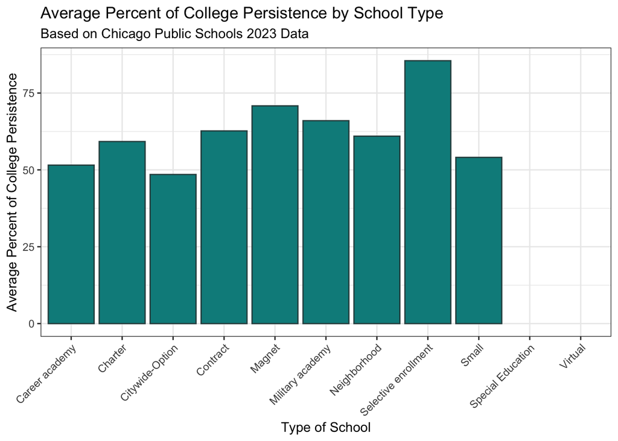

Figure 7: Avg College Persistence by School Type Graph

### Multivariable Analysis

In Figure 8, our explorations in research question 1 and research question 2 start to merge. The figure shows the positive relation between college enrollment and college persistence percent. The higher percent of college enrollment lends itself to a higher percent in college persistence. This confirms all the school type relationships explored above and goes further into the distribution of charter schools. As indicated by the orange points, charter school have a wider variation in college enrollment and college persistent rates.

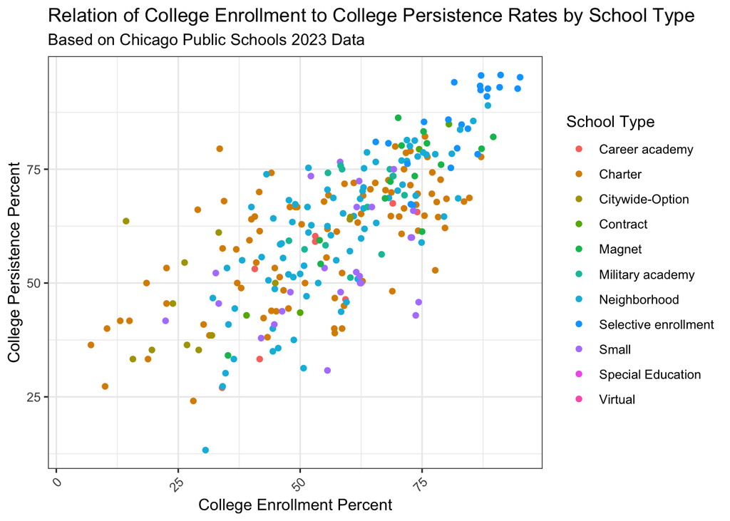

Figure 8: College Enrollments Vs College Persistence by School Type Graph

In Figure 9, the relation between graduation rates within four years and college enrollments percents are compared. This supports the positive association the correlation plot showed above. However, this scatterplot gives more insight on how the graduation rate is distributed between school types. In Figure 9, citywide option is very clearly at the lower end of the graph by itself. Meanwhile even though other schools linger towards the 50% and 75% graduation rate, across all other school types the graduation rates in four years in leaning more towards around 75% or greater.

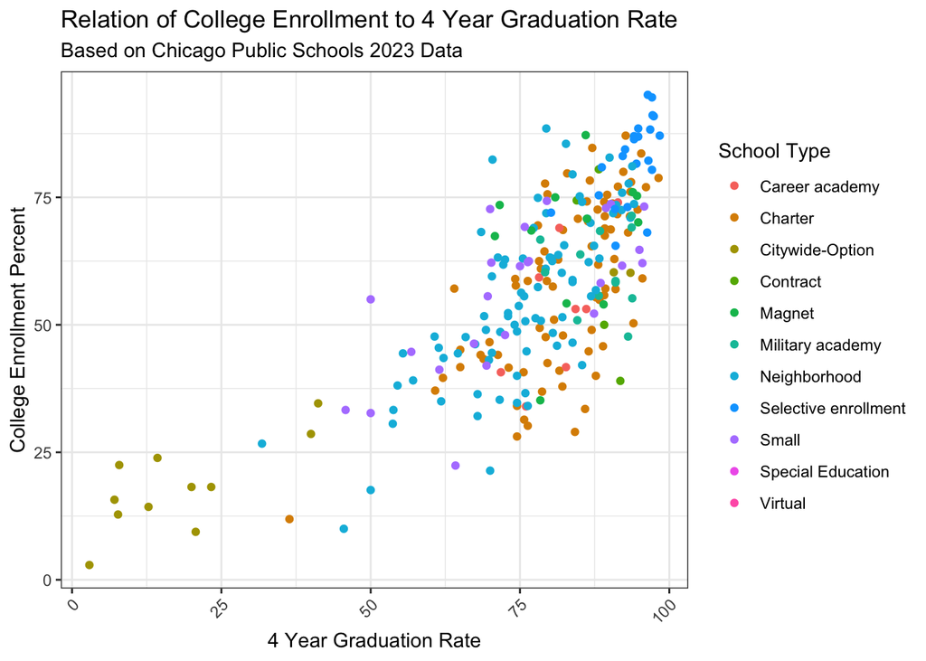

Figure 9: College Enrollments Versus 4 Year Graduation Rates Graph

It should be noted that in the Chicago Public Schools dataset, there are two different variables between graduation rates in four years and graduation rates in five years. According to the codebook and Chicago Public Schools website, the five year graduation program was created as a way to further encourage graduation rates among students. In Figure 10, it is clear that schools that have a high five year graduation rate also have a strong four year graduation rate. We can see that for small and neighborhood schools, the five year graduation rate option does not really affect or increase the four year graduation rate.

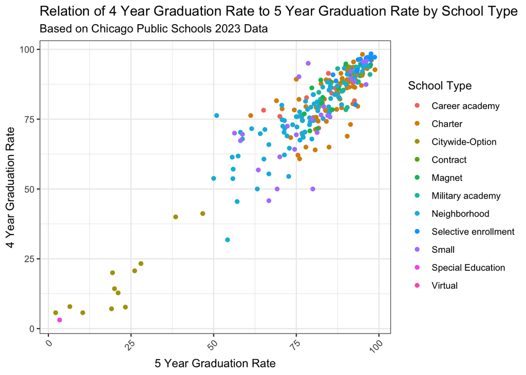

Figure 10: 5 Year Vs 4 Year Graduation Rate Graph

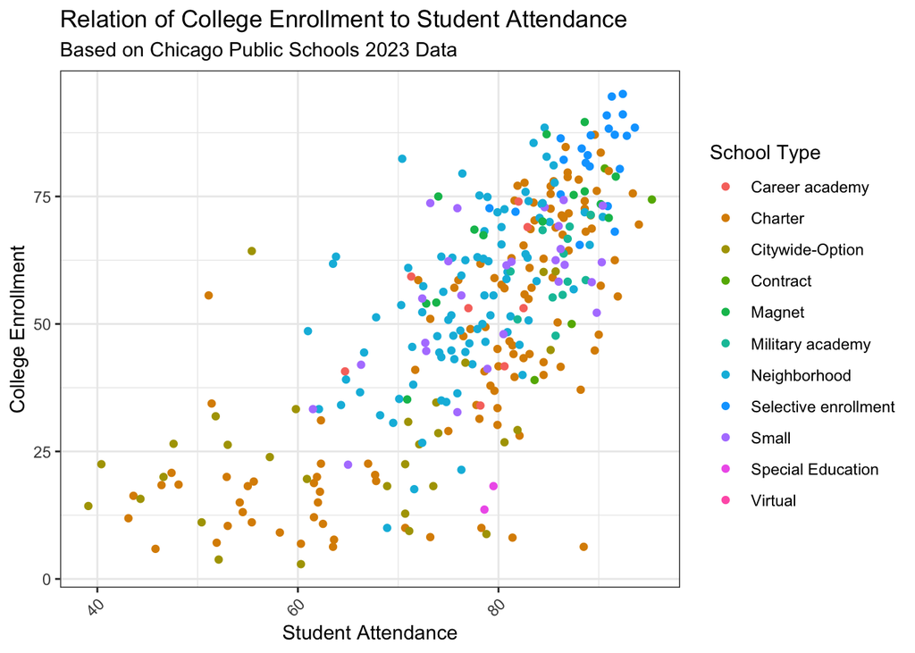

Figure 11: Student Attendance by School Type Graph

## Conclusions

From this data analysis, I discovered that college enrollment can be positively and negatively impacted by many variables. This is encouraging to schools as this means there are multiple ways they can further improve their college enrollment rates. If a school wants to improve college enrollments rates, they can focus on tackling student attendance. It was clear that there is a positive association between students attending class and college enrollment rates. Even though college persistence rates and graduation rates in four and five years were also strongly associated to college enrollments, it is a less manageable variable for schools to control on a daily basis. Student attendance is an manageable, and achievable variable to for schools to target that could show impactful results.

Schools can also choose to decrease the variables that have strong negative association with college enrollments. As mentioned in the code book, mobility rates measure the number times a student enrolls or leaves a school. Another was variable negatively association with college enrollments was chronic truancy rates which measures percentage of students who miss nine or more days of an average 180-day school year. While mobility rates many times are outside of a school’s control, chronic truancy rates once again relate to student attendance. If a school wishes to increase their attendance among students they could further compartmentalize it to first decrease the percent of chronic truancy among students. The one year drop out rate is also a variable that negatively affects the college enrollment rates. A one year drop out rate is a percent that measures any student who drops from the school’s roster for any reason. Once again, this variable many times is outside of a school’s control but still puts an emphasis on the importance of school attendance and persistence in attendance.

It is very clear that among school types, selective enrollment schools is keeping students in school and performing well. While many of these factors may be related to exterior forces as explored in the income levels. I am curious and hopeful for Chicago Public Schools to be able to look at methods used by selective enrollments schools and apply it to other schools. While some of these practices may be possible due to a larger budget, I am curious to further research what kind of practices could exist that are cost efficient and reproducible. What are selective enrollment schools doing to keep their student attendance up and how can other schools replicate this?

Overall, I was surprised to find out how many different types of schools exist in the CPS system. While many of these school may not measure their success on college enrollment, it is still interesting to see what determining variables could be associated with it. I was surprised on the variety of results across different school types. It is clear that schools such as charter and neighborhood schools did not have a consistent type of performance across the variables explored like selective enrollment schools. I am curious to further explore what is the differentiating feature within a school type like charter or neighborhood schools if it is not school type. Is it location, income, funding or are there other variables affecting it?

## References

CPS, (2025). Chicago Public Schools 2024 Report. [Chicago Public Schools Data Set Description](https://data.cityofchicago.org/Education/Chicago-Public-Schools-School-Progress-Reports-SY2/twrw-chuq/about_data).

Chicago, C. of. (2025, January 23). ACS 5 year data by Community Area: City of Chicago: Data Portal. [Chicago Demographic Data](https://data.cityofchicago.org/Community-Economic-Development/ACS-5-Year-Data-by-Community-Area/t68z-cikk/about_data).